# BiomassTutorial

Dheeraj Ralhan & Audrey Salerno

15/11/2023

# Overview

```r
library(tidyverse)
library(pool)
library(zoo)
library(TapeR)
```

In this RMarkdown, you will see some of the functionality in Markdown while also learning how to calculate above ground biomass for living and standing deadwood trees. All of the actual useful stats comes from the one and only Dheeraj!! :)

# 1. Data collection

## 1.1 Allometric equations

Here, we’re acquiring the data from the dataset “biomass_eq” which contains the all important allometric equations for calculation LIVE tree biomass

### Allometric equations for LIVE tree biomass

We are pulling out…

- Branch biomass
- Foliage biomass
- Root biomass
- Stem biomass

**You’ll notice that two forms of columns are being pulled for each equation. This is because there are two versions of each equation to fit both dbh thresholds - i.e. 6 cm and 10 cm**

```r
eq <- tbl(KELuser, "biomass_eq") %>%
  collect() %>%
  mutate(branches_mass_f = gsub("ba_live_60", "ba_live_100", branches_mass_f),
         foliage_mass_f = gsub("ba_live_60", "ba_live_100", foliage_mass_f), #syntax for gsub: gsub(pattern, replacement, x)
         root_mass_f = gsub("ba_live_60", "ba_live_100", root_mass_f),
         stem_mass_f = gsub("ba_live_60", "ba_live_100", stem_mass_f))
```

```r
str(eq)
```

```
## tibble [66 × 6] (S3: tbl_df/tbl/data.frame)
##  $ id             : int [1:66] 52 5 3 4 1 63 64 65 66 2 ...
##  $ species        : chr [1:66] "Juniperus communis" "Pinus sylvestris" "Pinus cembra" "Pinus mugo" ...
##  $ branches_mass_f: chr [1:66] "exp(-3.248 + 2.3695 * log(dbh_mm * 0.1) + (-0.0254 * ba)) * 1.00258646540519" "exp(-3.6641 + 2.1601 * log(dbh_mm * 0.1)) * 1.04508984648314" "exp(-3.6641 + 2.1601 * log(dbh_mm * 0.1)) * 1.04508984648314" "exp(-3.6641 + 2.1601 * log(dbh_mm * 0.1)) * 1.04508984648314…
##  $ foliage_mass_f : chr [1:66] "exp(-2.6019 + 2.1097 * log(dbh_mm * 0.1) + (-0.0404 * ba)) * 1.01325784347909" "exp(-2.4122 + 1.8683 * log(dbh_mm * 0.1) + (-0.0537 * ba)) * 1.03396760040159" "exp(-2.4122 + 1.8683 * log(dbh_mm * 0.1) + (-0.0537 * ba)) * 1.03396760040159" "exp(-2.4122 + 1.8683 * lo…
##  $ root_mass_f    : chr [1:66] "exp(-4.0287 + 2.4957 * log(dbh_mm * 0.1)) * 1.16862165974986" "exp(-3.6347 + 2.3038 * log(dbh_mm * 0.1)) * 0.950649723440268" "exp(-3.6347 + 2.3038 * log(dbh_mm * 0.1)) * 0.950649723440268" "exp(-3.6347 + 2.3038 * log(dbh_mm * 0.1)) * 0.950649723440268" ...
##  $ stem_mass_f    : chr [1:66] "exp(-2.7693 + 2.3761 * log(dbh_mm * 0.1) + (0.0072 * ba)) * 1.03850427882888" "exp(-2.3583 + 2.308 * log(dbh_mm * 0.1)) * 1.03342764129309" "exp(-2.3583 + 2.308 * log(dbh_mm * 0.1)) * 1.03342764129309" "exp(-2.3583 + 2.308 * log(dbh_mm * 0.1)) * 1.03342764129309" .…
```

Allometric equations based on species/genus

### Wood density ~ n = 300

Wood density values are crucial for calculation LIVE & DEAD biomass since it provide species/genus-specific values of wood density derived from the global wood density database - Harmon et al. (2008).

```r
wood_density <- tbl(KELuser, "wood_density") %>%
  collect() # unit (g cm^3) as live wood density mass
```

## 1.2 Plot-selection

This is a useful feature for filtering your dataset to fit your desired plots for your study. So when you acquire data from the database, it will provide all the information pertaining to your plots you wish to investigate.

```r
plot.id <- tbl(KELuser, "plot") %>%
  filter(foresttype %in% c("beech", "spruce"),
         country %in% "Romania",
         census %in% 1, # for multiple censuses, used c(1:3) for up to 3 censuses, e.c.t.
         plottype %in% c(2,3,4,8)) %>% # selecting circular plots
  pull(id)
```

# 2. Tree-level data (living)

## 2.1 Live [standing] trees

```r
tree.live <- tbl(KELuser, "tree") %>%
  filter(plot_id %in% plot.id, # identify plots you want
         status %in% c(1:4), # specifying live trees
         !onplot %in% c(0, 99), # ! means to exclude those selections
         dbh_mm >= 100, # setting the dbh threshold to 10 cm
         !species %in% "99") %>%
  inner_join(., tbl(KELuser, "plot"), by = c("plot_id" = "id")) %>%
  select(plot_id, plotsize, treeid, species, dbh_mm) %>%
  collect() %>%
  ungroup()
```

**Always good to visualize your data**

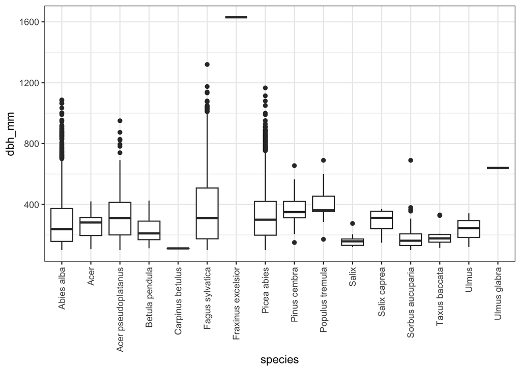

```r
tree.live %>%
  ggplot() +
  geom_boxplot(aes(x=species, y=dbh_mm))+
  theme_bw()+
  theme(axis.text.x = element_text(angle = 90, vjust = 0.5, hjust=1))
```

## 2.2 Basal area (living)

Some species/genus require the use of basal area as a secondary coefficient for calculating biomass, which is why we calculate it here

```r
ba.live <- tree.live %>%
  mutate(dbh_cm = dbh_mm * 0.1,
         ba_100 = pi * dbh_mm ^2 / 4 / 1000000) %>%  # 1000000 mm per square metres
  group_by(plot_id, plotsize) %>%
  summarise(ba = round(sum(ba_100) * 10000 / first(plotsize), 4)) %>% # cross sectional area of trees per plot
  ungroup()
```

**DBH (living)**

*Optional step, if you wish to have mean plot-level dbh in a separate dataframe*

```r
dbh.live <- tree.live %>%
  group_by(plot_id) %>%
  summarise(dbh_live_100 = round(mean(dbh_mm), 0)) %>%
  ungroup()
```

## 2.3 Biomass (living)

### Calculate aboveground biomass on tree scale

```r
biomass.tree <- tree.live %>%
  left_join(., eq, by = "species") %>%        # Specifying the allometric equations
  left_join(., ba.live, by = "plot_id") %>%   # Basal area data
  rowwise() %>% # perform the operation over the rows
  mutate(plotsize = plotsize.x,
         BM = eval(parse(text = branches_mass_f)), # Branch mass
         FM = eval(parse(text = foliage_mass_f)),  # Foliage mass
         SM = eval(parse(text = stem_mass_f)),     # Stem mass
         RM = eval(parse(text = root_mass_f)),     # Root mass, if necessary to calculate
         biomass_tree_total = BM + FM + SM + RM,
         biomass_tree_above = BM + FM + SM,
         biomass_tree_below = RM,
         biomass_tree_stem = SM,
         biomass_tree_foliage = BM + FM) %>%
  select(-plotsize.x, -plotsize.y) %>% # Caveat to removed duplicated columns. I'm sure there's a better way
  ungroup()
```

### Upscale from tree to plot scale [t/ha]

Using the tree-level estimate, here we upscale biomass to one hectare for each plot represented in Mg ha^1 or t ha^1.

```r
biomass.plot <- biomass.tree %>%
  group_by(plot_id) %>%
  summarise(plotsize = first(plotsize), # since plot size varies, it's important to use the first value for each row [i.e. plot]
            ntrees_live = n(),
            biomass_plot_total = sum(biomass_tree_total),
            biomass_plot_total.sd = sd(biomass_tree_total), # total contains root mass
            biomass_plot_above = sum(biomass_tree_above),
            biomass_plot_above.sd = sd(biomass_tree_above),
            biomass_plot_below = sum(biomass_tree_below),
            biomass_plot_stem = sum(biomass_tree_stem),
            biomass_plot_foliage = sum(biomass_tree_foliage)) %>%
  mutate_at(vars(-plot_id, -plotsize, -ntrees_live), funs(. * 10 / plotsize)) %>%
  mutate_at(vars(-plot_id, -plotsize, -ntrees_live), funs(round(., 2))) %>%
  select(-plotsize) %>%
  ungroup()
```

[output not shown]

[output not shown]

*Ignore the warning*

### Visualize subset of plots

I just selected a subset of plots (not random) and trimmed the species just to look at total biomass by plot by species.

```
## Warning: There were 2 warnings in `filter()`.
## The first warning was:
## ℹ In argument: `plot_id == c(188, 269, 290, 398, 477)`.
## Caused by warning in `==.default`:
## ! longer object length is not a multiple of shorter object length
## ℹ Run `dplyr::last_dplyr_warnings()` to see the 1 remaining warning.
```

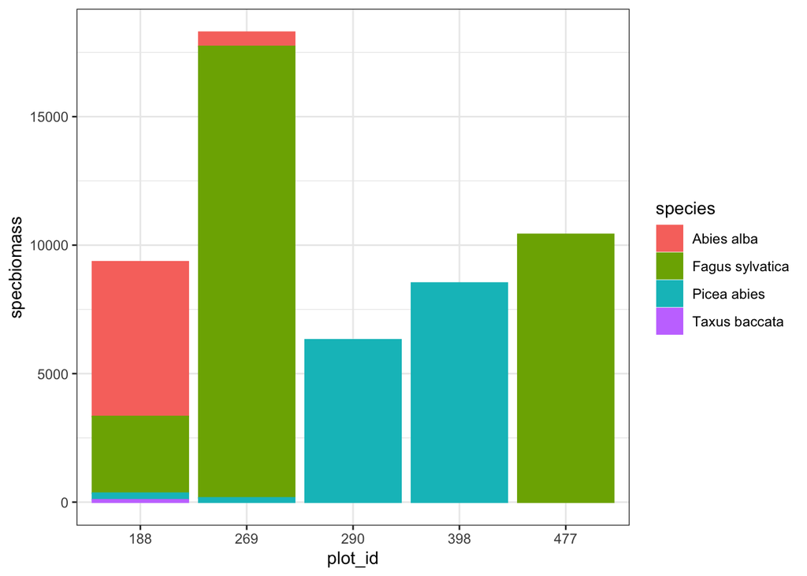

```r
#table(biomass.tree$species)
biomass.tree %>%
   mutate(plot_id = as.factor(biomass.tree$plot_id)) %>%
  select(plot_id, species, biomass_tree_total) %>%
  filter(plot_id == c(188, 269, 290, 398, 477)) %>%
  group_by(plot_id, species) %>%
  summarise(specbiomass=sum(biomass_tree_total)) %>%
  ggplot() +
  geom_col(aes(x=plot_id,y=specbiomass,
                       fill=species,
                       color=species)) +
  theme_bw()
```

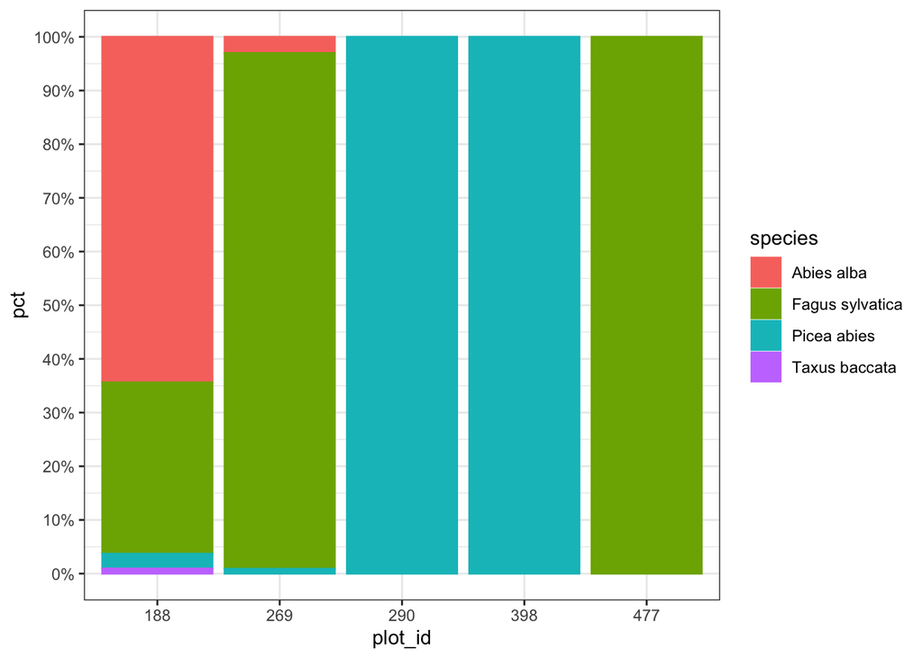

```r
biomass.tree %>%
   mutate(plot_id = as.factor(biomass.tree$plot_id)) %>%
  select(plot_id, species, biomass_tree_total) %>%
  filter(plot_id == c(188, 269, 290, 398, 477)) %>%
  group_by(plot_id, species) %>%
  summarise(specbiomass=sum(biomass_tree_total)) %>%
  group_by(plot_id) %>%
  mutate(pct = specbiomass/sum(specbiomass)) %>%
  ggplot() +
  geom_col(aes(x=plot_id,y=pct,
                       fill=species,
                       color=species)) +
  scale_y_continuous(labels = scales::percent, # calling function percent from the scales package
                     breaks = seq(0,1,by=0.1)) +
  theme_bw()
```

# 3.Tree level - dead [snags]

## Gather data

```r
tree.dead <- tbl(KELuser, "tree") %>%
  filter(plot_id %in% plot.id,
         !onplot %in% c(0, 99),
         status %in% c(11:13,15,17:23), # Selecting dead trees only
         dbh_mm >= 100,
         !decayht %in% 99,
         !species %in% "99",
         decay %in% c(1:5) | decay_wood %in% c(1:5)) %>%
  inner_join(., tbl(KELuser, "plot"), by = c("plot_id" = "id")) %>%
  select(plot_id, plotsize, treeid, species, dbh_mm, decay, decay_wood, decayht) %>%
  collect()
```

## 3.1 Basal area (dead)

```r
ba.dead <- tree.dead %>%
  mutate(ba = pi * dbh_mm ^ 2 / 4 / 1000000) %>%
  group_by(plot_id) %>%
  summarise(ba_dead_100 = round(sum(ba) * 10000 / first(plotsize), 4)) %>%
  ungroup()
```

## 3.2 DBH (dead)

```r
dbh.dead <- tree.dead %>%
  group_by(plot_id) %>%
  summarise(dbh_dead_100 = round(mean(dbh_mm), 0)) %>%
  ungroup()
```

**Join living and dead dbh if you need to**

```r
dbh <- dbh.live %>% left_join(., dbh.dead, by = "plot_id") # if necessary
```

## 3.3 Biomass (dead)

Calculate aboveground biomass on tree scale. Dead standing and downed biomass do not use the allometric equations for calculating biomass. Instead, we use the ‘TapeR’ package to help predict the tree height of all individuals using ‘decayht’ which is identified during forest inventories.

### Taper model for calculation of the tree volume

```r
data(SK.par.lme)

necromass.tree <- tree.dead %>%
  mutate(decayht = case_when(
    decayht == 0 ~ 5,
    decayht == 1 ~ 15,
    decayht == 2 ~ 25,
    decayht == 3 ~ 35,
    decayht == 4 ~ 45,
    decayht == 5 ~ 55),
    decay_class = ifelse(decay_wood %in% 99, round(0.2924953 + 0.7131269 * decay, 0), decay_wood)) %>%
  left_join(., wood_density, by = c("species", "decay_class")) %>%
  rowwise() %>%
  mutate(volume_snag = E_VOL_AB_HmDm_HT.f(Hm = 1.3, Dm = (dbh_mm * 0.1),
                                          mHt = (log(dbh_mm * 0.1)-1.08261)^2/0.275541, sHt = 0, par.lme = SK.par.lme,
                                          A = 0, B = decayht, iDH = "H")$E_VOL,
         dead_tree_biomass = volume_snag * (density_gCm3 * relative_density * 1000)) %>%
  ungroup()
```

In this step, we first predicted the height of each dead standing tree, calculating its volume then biomass. Once predicted tree height is calculated, the latter part of the script uses this value to first calculate dead standing tree volume, which is converted into biomass.

### Upscale from tree to plot scale [t/ha]

```r
necromass.plot <- necromass.tree %>%
  group_by(plot_id) %>%
  summarise(plotsize = first(plotsize),
            ntrees_dead = n(),
            dead_standing = round(sum(dead_tree_biomass) * 10 / plotsize, 2),
            dead_standing.sd = round(sd(dead_tree_biomass) * 10 / plotsize, 2)) %>%
  select(-plotsize) %>%
  ungroup()
```

## 3.4 Deadwood - transect

```r
deadwood.transect <- tbl(KELuser, "deadwood")  %>%
  filter(plot_id %in% plot.id,
         !species %in% "99",
         !decay %in% 99) %>%
  inner_join(., tbl(KELuser, "plot"), by = c("plot_id" = "id")) %>%
  filter(date < 2014 & dbh_mm >= 100 | date >= 2014 & dbh_mm >= 60) %>% # adjust, accordingly
  select(plot_id, species, decay, dbh_mm) %>%
  collect()
```

**Transect deadwood: Upscale to plot level [Mg ha]**

```r
biomass.lying.transect <- deadwood.transect %>%
  filter(dbh_mm >= 100) %>%
  left_join(., wood_density, by = c("species", "decay" = "decay_class")) %>%
  group_by(plot_id, species, decay) %>%
  summarise(volume = ((pi ^ 2 * sum((dbh_mm * 0.001) ^ 2)) / 800) * 10000,
            biomass = volume * (first(density_gCm3) * first(relative_density) * 1000),
  ) %>%
  group_by(plot_id) %>%
  summarise(biomass_lying_transect = round(sum(biomass) / 1000, 2),
            biomass_lying_transect.sd = round(sd(biomass) / 1000, 2)) %>%
  ungroup()
```

# 4. Plot-level biomass

Now that we have biomass summed at the plot-level for live and dead standing trees, we are now ready to merge the datasets today, to obtain a total biomass value for each plot

```r
{plot_biomass <- biomass.plot %>%
  full_join(., necromass.plot, by = "plot_id") %>% # Dead standing biomass
  full_join(., biomass.lying.transect, by = "plot_id") %>% # Dead downed / CWD
  replace(., is.na(.), 0) %>%
  summarise(n_total = ntrees_live + ntrees_dead,
            n_live = ntrees_live,
            n_dead = ntrees_dead,
            total_standing = biomass_plot_above + dead_standing + biomass_lying_transect,
            total_standing.sd = biomass_plot_above.sd + dead_standing.sd + biomass_lying_transect.sd,
            live = biomass_plot_above,
            live.sd = biomass_plot_above.sd,
            dead_standing = dead_standing,
            dead_standing.sd = dead_standing.sd,
            dead_cwd = biomass_lying_transect,
            dead_cwd.sd = biomass_lying_transect.sd)

remove(ba.dead, ba.live, biomass.plot, biomass.tree, dbh, dbh.dead, dbh.live, eq,
       deadwood.transect, biomass.lying.transect, SK.par.lme,
       necromass.tree, necromass.plot, tree.dead, tree.live, wood_density)
}
```

# 5. Disconnect

```r
poolClose(KELuser); remove(KELuser)
#closeAllConnections(); rm(list=ls())
```